# Course Project for Practical Machine Learning

Nicco Reggente

Saturday, September 20, 2014

First, we will move into the directory in which the data is contained. This will need to be changed on a person-to-person basis. This should be the only hard-coding throughout the script.We will also want to make sure that the caret package is available and loady into the workspace.

```r
setwd("C:/Users/Nicco/Dropbox/CourseRA_Notes/Data Science Specilization/Practical Machine Learning/Course_Project/PML-Course-Project")

library("caret")
```

```r
PML_Raw_Data<-read.csv(file="pml-training.csv")
attach(PML_Raw_Data)
```

The first thing we want ot do is trim ourdataset to only consider the features of interest. We only want to use information from the acceleromaters positions on different parts of the body. Each of these has an axis of rotation, so we want to catpure all of them.We can do this by searching for patterns that begin with *accel*. This can be accomplished in R with variations on the glob2rx and grep() functions that, then, index the original data set to “trim” it to only contain the features of interest.

```r
str_match_command<-glob2rx("accel*")

feature_set<-PML_Raw_Data[ ,grep(str_match_command,names(PML_Raw_Data))]
```

Now, we will want to create a data partition that splits our data into a training and testing set (within this training set) in a cross-validation fashion. The function *createFolds* will accomplish this by crating a set of indices. 10 folds should suffice and give us an estimate of our out-of-sample error rate.

```r
intrain_cv_indices<-createFolds(classe,k=10,list=TRUE,returnTrain=TRUE)
```

Now, we want to loop over our cross validation indices so that we can train and test on subsets of non-overlapping data. We will do this by indexing our patterns (the variable named *feature_set*) and our labels (the variable names *classe*) by the *intrain_cv_indices_variable*. In this case, we will use a *linear svm* as our training classifier for its ability to sift through unimportant data. We will also center and scale our data before allowing them to be used as features.

After we build a model, we will test it on the left-out data, get predictions, and prepare those predictions to our actual testing labels. This is akin to comparing our Y values to our Y-hat values in regression.

We will iteratively concatenate these accuracies and average at the end of the cross-validation folds.

Lastly, we will save metrics *Accuracy* and *Kappa* to estimate the out-of-sample error for our model.

This for-loop will output to the user the current cross-validation that the classifier is on, so that the user is not left in the dark.

NOTE TO GRADER: For the sake of html compilation time, I am only going to run this loop once. I have commented out the portion of the for-loop that will loop over each index of the cross-validation. This will only run once instead of 10 times for the 10-fold cross-validation. This makes it similar to if I had just used the createdatapartiion script instead of createfolds.

```r
Accuracy<-0
Kappa<-0
P_Value<-0

#for (i in 1:length(intrain_cv_indices)) {

for (i in 1:1) {

  print(paste("Currently on CV Number ",i))
  cur_training_indices<-unlist(intrain_cv_indices[i],recursive=FALSE,use.names=FALSE)

  cur_training_data<-feature_set[cur_training_indices, ]
  cur_training_labels<-classe[cur_training_indices]

  fit<-train(cur_training_data,cur_training_labels,method="svmLinear",preProc=c("center","scale"))

  cur_testing_data<-feature_set[-cur_training_indices, ]
  cur_testing_labels<-classe[-cur_training_indices]


  predictions<-predict(fit,newdata=cur_testing_data)

  Confusion_Matrix<-as.table(confusionMatrix(predictions,cur_testing_labels)$overall)

  Accuracy[i]<-Confusion_Matrix[1]
  Kappa[i]<-Confusion_Matrix[2]
  P_Value[i]<-Confusion_Matrix[6]

}
```

```
## [1] "Currently on CV Number  1"
```

```r
CV_Accuracy<-mean(Accuracy)
CV_Kappa<-mean(Kappa)
CV_P_Value<-mean(P_Value)
```

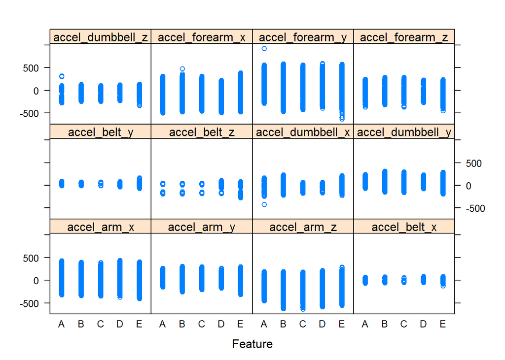

```r
featurePlot(cur_training_data,cur_training_labels)
```

It seems as though these features have some relation to the outcome variables. Also, finally, We should look at the average results and asses the predictive powers of our model, according to the cross-validation.

```r
CV_Accuracy
```

```
## [1] 0.5372
```

```r
CV_Kappa
```

```
## [1] 0.4062
```

```r
CV_P_Value
```

```
## [1] 1.528e-121
```